# Momocs speed dating

## Graphics

### `tps_*`: Thin Plate Splines

TPS have not been presented before but here there are:

[output not shown]

Again, plenty options in `?tps_*`.

You may also like lolliplots and friends:

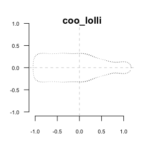

```r
coo_lolli(beer, whisky); title("coo_lolli")
```

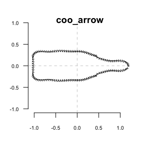

```r
coo_arrows(beer, whisky); title("coo_arrow")
```

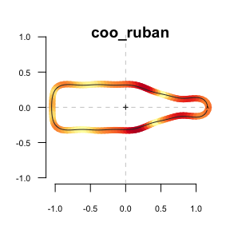

```r
# an example with coo_ruban
coo_plot(beer) # to get the first plot
coo_ruban(beer, edm(beer, whisky), lwd=8) # we add ruban based from deviations
coo_draw(whisky)
title("coo_ruban")
```

### `ggplot2`

Many graphical function have their `ggplot2` counterpart:

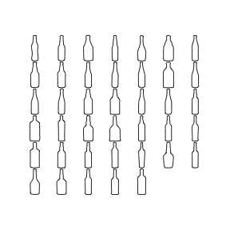

```r
panel(bot)
```

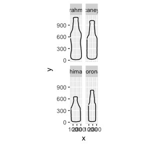

```r
panel2(slice(bot, 1:4)) # for speed sake
```

And the classical `ggplot2` grammar applies:

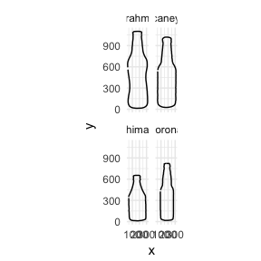

```r
library(ggplot2)
gg <- panel2(slice(bot, 1:4)) # for speed sake
gg + theme_minimal()
```

Otherwise, you can build your own plots. Let’s begin with a simple example:

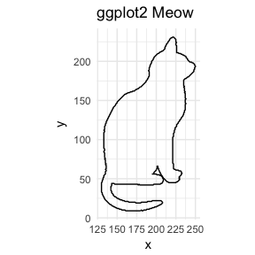

```r
# we build a ggplot object from a shape turned into a data.frame
shapes[4] %>% m2d() %>% ggplot() +
  aes(x, y) + geom_path() + coord_equal() +
  labs(title="ggplot2 Meow") + theme_minimal()
```

Here is a more complicated plot that takes profit of `as_df` methods that turns objects into `ggplot2`-friendly `data.frame`s:

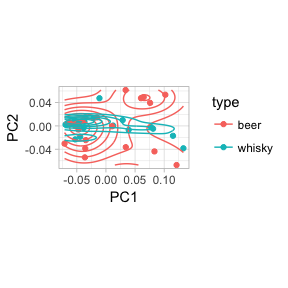

```r
bot.p %>% as_df() %>% ggplot() +
  aes(x=PC1, y=PC2, col=type) + coord_equal() +
  geom_point() + geom_density2d() + theme_light()
```

### Color palettes

- Nice palettes are bundled with Momocs, see `?Palettes`.
- Overall, RColorBrewer is more than an option if you work with colors.

## Frequently asked questions

- **How to access all methods for a given class?**
  - `methods(class="your_class")`, eg `methods(class="Opn")`
- **How to access methods defined for a particular function?**
  - `methods("your_function")`, eg `methods("fgProcrustes")`
- **How can I access help for a particular methods?**
  - `function.class`, eg `?plot.PCA`
- **How can I access the code of a method?**
  - For functions, just type its name, eg `lf_structure`; for methods add its class, eg `plot.PCA`
- **To be continued**
- Done with love by Vincent Bonhomme `<bonhomme.vincent@gmail.com>`.
- Help/suggestions/review/critics are welcome.
- Sources are [there](https://github.com/vbonhomme/Momocs/tree/master/vignettes)